# EDA

```python
ls
```

```
Agricultural_Output_and_Input_Analysis__A_Detailed_Documentation.pdf
EDA.ipynb
table01a.csv
table01.csv
Table02StateProductivityAccounts.csv
```

```
Summary for Dataset 1 (Table 1a: Price Indices and Implicit Quantities):
              Year          Value
count  4292.000000    4292.000000
mean   1984.500000   35955.504110
std      21.362498   75051.013707
min    1948.000000       0.021590
25%    1966.000000       0.479405
50%    1984.500000     119.868186
75%    2003.000000   32710.715498
max    2021.000000  465471.175200

Data Types:
Year           int64
Attribute     object
Value        float64
dtype: object

Missing Values:
Year         0
Attribute    0
Value        0
dtype: int64
==================================================
Summary for Dataset 2 (Table 1: Farm Outputs and Inputs):
              Year        Value
count  2220.000000  2220.000000
mean   1984.500000     0.882691
std      21.364822     0.485802
min    1948.000000     0.016234
25%    1966.000000     0.575640
50%    1984.500000     0.871742
75%    2003.000000     1.036172
max    2021.000000     4.570501

Data Types:
Year           int64
Attribute     object
Value        float64
dtype: object

```

[output cut: 22 more lines]

```
Units                    object
Year                      int64
Value                   float64
dtype: object

Missing Values:
ID                      0
Variable Name           0
Variable Description    0
State                   0
Units                   0
Year                    0
Value                   0
dtype: int64
==================================================
```

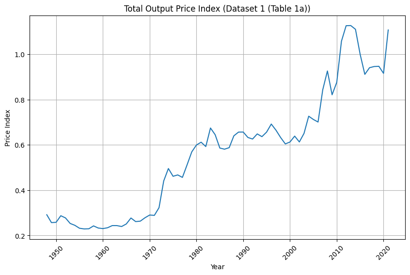

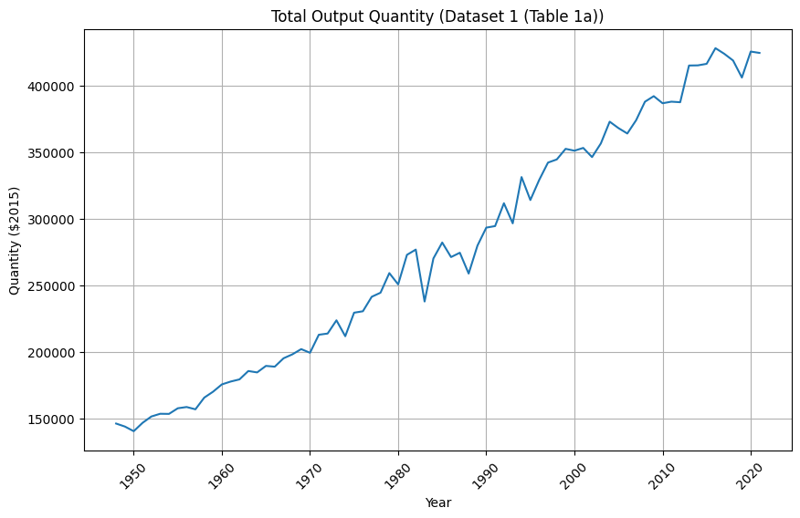

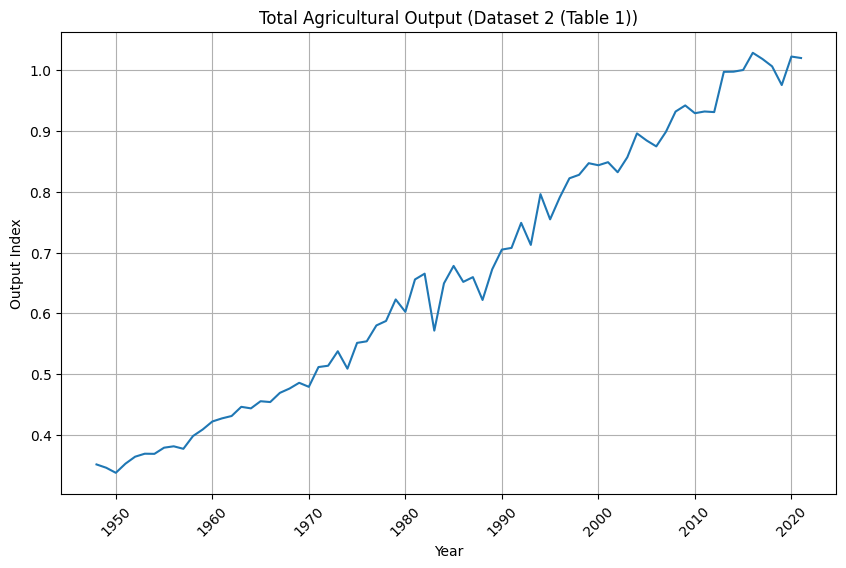

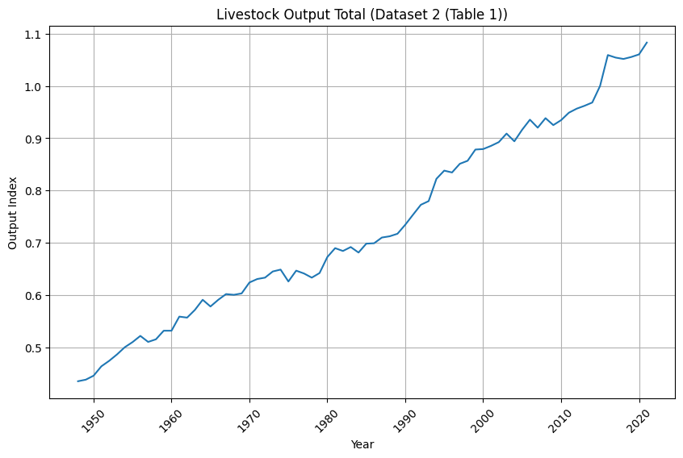

[figure not shown]

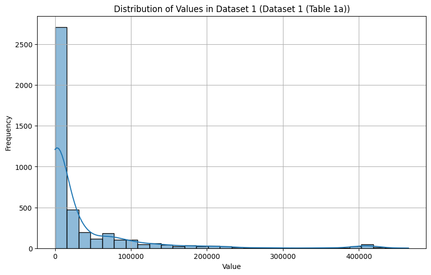

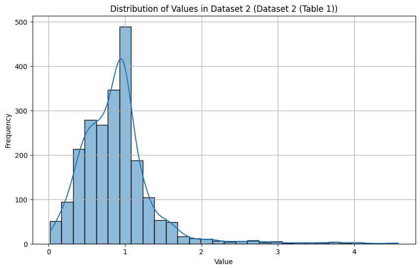

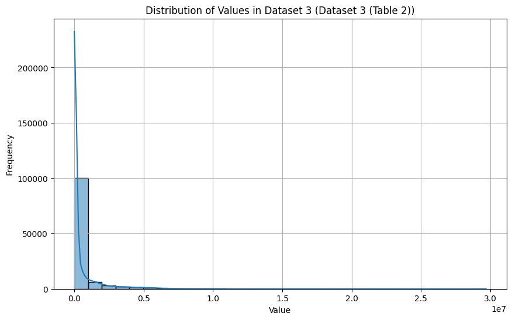

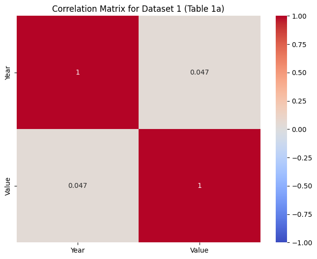

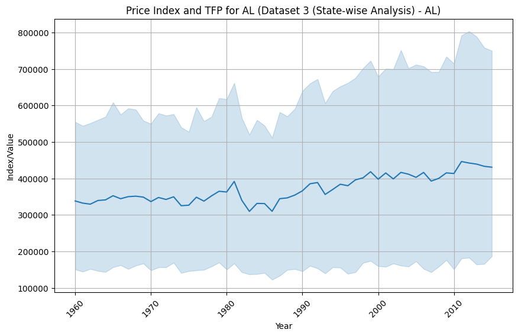

```python
import pandas as pd
import matplotlib.pyplot as plt
import seaborn as sns

# Load the datasets
dataset1 = pd.read_csv('table01a.csv')  # Price indices and implicit quantities
dataset2 = pd.read_csv('table01.csv')   # Total agricultural output indices
dataset3 = pd.read_csv('Table02StateProductivityAccounts.csv')  # TFP and price/quantity indices for states

# 1. Basic Statistics and Summary
def basic_statistics(df, dataset_name):
    print(f"Summary for {dataset_name}:")
    print(df.describe())
    print("\nData Types:")
    print(df.dtypes)
    print("\nMissing Values:")
    print(df.isnull().sum())
    print("="*50)

# Apply basic statistics to each dataset
basic_statistics(dataset1, "Dataset 1 (Table 1a: Price Indices and Implicit Quantities)")
basic_statistics(dataset2, "Dataset 2 (Table 1: Farm Outputs and Inputs)")
basic_statistics(dataset3, "Dataset 3 (Table 2: TFP, Prices, and Quantities by State)")

# 2. Visualizations for Trends and Distributions

# Function to plot time series for the datasets
def plot_time_series(df, dataset_name, x_col, y_col, title, xlabel, ylabel):
    plt.figure(figsize=(10, 6))
    sns.lineplot(x=df[x_col], y=df[y_col])
    plt.title(f"{title} ({dataset_name})")
    plt.xlabel(xlabel)
    plt.ylabel(ylabel)
    plt.xticks(rotation=45)
    plt.grid(True)
    plt.show()

# Dataset 1: Time Series for 'Total output: Price (index, 2015=1)' and 'Total output: Quantity (million, $2015)'
plot_time_series(dataset1[dataset1['Attribute'] == 'Total output: Price (index, 2015=1)'], 'Dataset 1 (Table 1a)', 'Year', 'Value', 'Total Output Price Index', 'Year', 'Price Index')
plot_time_series(dataset1[dataset1['Attribute'] == 'Total output: Quantity (million, $2015)'], 'Dataset 1 (Table 1a)', 'Year', 'Value', 'Total Output Quantity', 'Year', 'Quantity ($2015)')

# Dataset 2: Time Series for 'Total agricultural output' and 'Livestock and products output: Total'
plot_time_series(dataset2[dataset2['Attribute'] == 'Total agricultural output'], 'Dataset 2 (Table 1)', 'Year', 'Value', 'Total Agricultural Output', 'Year', 'Output Index')
plot_time_series(dataset2[dataset2['Attribute'] == 'Livestock and products output: Total'], 'Dataset 2 (Table 1)', 'Year', 'Value', 'Livestock Output Total', 'Year', 'Output Index')

# Dataset 3: Time Series for 'Total agricultural output price index' in Alabama (example for one state, 'AL')
plot_time_series(dataset3[dataset3['Variable Name'] == 'Total agricultural output price index'], 'Dataset 3 (Table 2)', 'Year', 'Value', 'Agricultural Output Price Index (AL)', 'Year', 'Price Index')

# 3. Histograms for Distributions
def plot_histogram(df, dataset_name, column, title, xlabel, ylabel):
    plt.figure(figsize=(10, 6))
    sns.histplot(df[column], kde=True, bins=30)
    plt.title(f"{title} ({dataset_name})")
    plt.xlabel(xlabel)
    plt.ylabel(ylabel)
    plt.grid(True)
    plt.show()

# Plot histograms for the 'Value' column in each dataset
plot_histogram(dataset1, 'Dataset 1 (Table 1a)', 'Value', 'Distribution of Values in Dataset 1', 'Value', 'Frequency')
plot_histogram(dataset2, 'Dataset 2 (Table 1)', 'Value', 'Distribution of Values in Dataset 2', 'Value', 'Frequency')
plot_histogram(dataset3, 'Dataset 3 (Table 2)', 'Value', 'Distribution of Values in Dataset 3', 'Value', 'Frequency')

# 4. Correlation Plot for Dataset 1 (with 'Value' for relevant attributes)
def plot_correlation(df, dataset_name):
    # Filter relevant columns for correlation plot
    df_filtered = df[['Year', 'Value']]  # Example with 'Year' and 'Value', modify as needed
    correlation_matrix = df_filtered.corr()

    plt.figure(figsize=(8, 6))
    sns.heatmap(correlation_matrix, annot=True, cmap='coolwarm', vmin=-1, vmax=1, center=0)
    plt.title(f"Correlation Matrix for {dataset_name}")
    plt.show()

plot_correlation(dataset1, 'Dataset 1 (Table 1a)')

# 5. State-wise Analysis (For Dataset 3, look at specific states like 'AL')
def state_analysis(df, state_code):
    df_state = df[df['State'] == state_code]
    plot_time_series(df_state, f"Dataset 3 (State-wise Analysis) - {state_code}", 'Year', 'Value', f"Price Index and TFP for {state_code}", 'Year', 'Index/Value')

# Example: Analyze Alabama (AL)
state_analysis(dataset3, 'AL')

# Additional Analysis (Optional): You can filter data based on attributes or years for further insights
```

```python
dataset1.head()
```

|  | Year | Attribute | Value |
| --- | --- | --- | --- |
| 0 | 1948 | Total output: Price (index, 2015=1) | 0.291915 |
| 1 | 1948 | Total output: Quantity (million, $2015) | 146514.353000 |
| 2 | 1948 | Livestock and products: All livestock and prod... | 0.267055 |
| 3 | 1948 | Livestock and products: All livestock and prod... | 71796.742360 |
| 4 | 1948 | Livestock and products: Meat animals: Price (i... | 0.185528 |

```python
dataset2.head()
```

|  | Year | Attribute | Value |
| --- | --- | --- | --- |
| 0 | 1948 | Total agricultural output | 0.351754 |
| 1 | 1948 | Livestock and products output: Total | 0.435704 |
| 2 | 1948 | Livestock and products output: Meat animals | 0.562957 |
| 3 | 1948 | Livestock and products output: Dairy | 0.449532 |
| 4 | 1948 | Livestock and products output: Poultry and eggs | 0.129304 |

```python
dataset3.head()
```

|  | ID | Variable Name | Variable Description | State | Units | Year | Value |
| --- | --- | --- | --- | --- | --- | --- | --- |
| 0 | 1 | Total agricultural output price index | Output price: Total | AL | Prices relative to Alabama in 1996 (AL 1996 = 1) | 1960 | 0.338578 |
| 1 | 2 | Total agricultural output price index | Output price: Total | AL | Prices relative to Alabama in 1996 (AL 1996 = 1) | 1961 | 0.336136 |
| 2 | 3 | Total agricultural output price index | Output price: Total | AL | Prices relative to Alabama in 1996 (AL 1996 = 1) | 1962 | 0.354728 |
| 3 | 4 | Total agricultural output price index | Output price: Total | AL | Prices relative to Alabama in 1996 (AL 1996 = 1) | 1963 | 0.345165 |
| 4 | 5 | Total agricultural output price index | Output price: Total | AL | Prices relative to Alabama in 1996 (AL 1996 = 1) | 1964 | 0.339705 |

```python
for d in [dataset1, dataset2, dataset3]:
    print(d.sample(10))  # Prints a random sample of 10 rows from each dataset
    print(d.columns)  # Prints the column names
    print('Columns:')
    for c in d.columns:
        print(c, "unique values:", d[c].unique(), "<--unique and nunique-->", d[c].nunique())  # Use the column data for unique and nunique
```

```
      Year                                          Attribute          Value
874   1963  Livestock and products: Meat animals: Price (i...       0.151295
3076  2001  Livestock and products: All livestock and prod...       0.624868
487   1956   Crops: Other crops 2/: Quantity (million, $2015)   12720.214580
910   1963          Labor: Hired labor: Price (index, 2015=1)       0.060284
2368  1988  Intermediate inputs: Energy: Price (index, 201...       0.238273
2453  1990        Crops: Oil crops: Quantity (million, $2015)   20440.620340
4013  2017        Crops: All crops: Quantity (million, $2015)  216154.736800
2047  1983        Crops: Oil crops: Quantity (million, $2015)   17336.435870
2788  1996  Livestock and products: Meat animals: Price (i...       0.456066
565   1957  Labor: Self-employed and unpaid family workers...  147203.272800
Index(['Year', 'Attribute', 'Value'], dtype='object')
Columns:
Year unique values: [1948 1949 1950 1951 1952 1953 1954 1955 1956 1957 1958 1959 1960 1961
 1962 1963 1964 1965 1966 1967 1968 1969 1970 1971 1972 1973 1974 1975
 1976 1977 1978 1979 1980 1981 1982 1983 1984 1985 1986 1987 1988 1989
 1990 1991 1992 1993 1994 1995 1996 1997 1998 1999 2000 2001 2002 2003
 2004 2005 2006 2007 2008 2009 2010 2011 2012 2013 2014 2015 2016 2017
 2018 2019 2020 2021] <--unique and nunique--> 74
Attribute unique values: ['Total output: Price (index, 2015=1)'
 'Total output: Quantity (million, $2015)'
 'Livestock and products: All livestock and products 1/: Price (index, 2015=1)'
 'Livestock and products: All livestock and products 1/: Quantity (million, $2015)'
 'Livestock and products: Meat animals: Price (index, 2015=1)'
 'Livestock and products: Meat animals: Quantity (million, $2015)'
 'Livestock and products: Dairy: Price (index, 2015=1)'
 'Livestock and products: Dairy: Quantity (million, $2015)'
 'Livestock and products: Poultry and eggs: Price (index, 2015=1)'
 'Livestock and products: Poultry and eggs: Quantity (million, $2015)'
 'Crops: All crops: Price (index, 2015=1)'
 'Crops: All crops: Quantity (million, $2015)'
 'Crops: Food grains: Price (index, 2015=1)'
 'Crops: Food grains: Quantity (million, $2015)'
 'Crops: Feed crops: Price (index, 2015=1)'
 'Crops: Feed crops: Quantity (million, $2015)'
 'Crops: Oil crops: Price (index, 2015=1)'
 'Crops: Oil crops: Quantity (million, $2015)'
 'Crops: Vegetables and melons: Price (index, 2015=1)'
 'Crops: Vegetables and melons: Quantity (million, $2015)'
 'Crops: Fruits and tree nuts: Price (index, 2015=1)'
```

[output cut: 177 more lines]

```
 'Input quantity index: Intermediate inputs: Other intermediate inputs'
 'Total factor productivity'] <--unique and nunique--> 43
State unique values: ['AL' 'AR' 'AZ' 'CA' 'CO' 'CT' 'DE' 'FL' 'GA' 'IA' 'ID' 'IL' 'IN' 'KS'
 'KY' 'LA' 'MA' 'MD' 'ME' 'MI' 'MN' 'MO' 'MS' 'MT' 'NC' 'ND' 'NE' 'NH'
 'NJ' 'NM' 'NV' 'NY' 'OH' 'OK' 'OR' 'PA' 'RI' 'SC' 'SD' 'TN' 'TX' 'UT'
 'VA' 'VT' 'WA' 'WI' 'WV' 'WY'] <--unique and nunique--> 48
Units unique values: ['Prices relative to Alabama in 1996 (AL 1996 = 1)'
 'Implicit quantities (in 1996 AL thousand dollars)'
 'Quantity index relative to Alabama in 1996 (AL 1996 = 1)'
 'TFP index (AL 1996 = 1)'] <--unique and nunique--> 4
Year unique values: [1960 1961 1962 1963 1964 1965 1966 1967 1968 1969 1970 1971 1972 1973
 1974 1975 1976 1977 1978 1979 1980 1981 1982 1983 1984 1985 1986 1987
 1988 1989 1990 1991 1992 1993 1994 1995 1996 1997 1998 1999 2000 2001
 2002 2003 2004 2005 2006 2007 2008 2009 2010 2011 2012 2013 2014 2015] <--unique and nunique--> 56
Value unique values: [0.33857781 0.33613602 0.3547284  ... 0.63256979 0.61496407 0.62187648] <--unique and nunique--> 115503
```

# Agricultural Data Analysis

## **Introduction**

Agriculture is vital for economic growth and sustainability, providing food, raw materials, and income. The datasets analyzed in this project give an overview of agricultural practices, including price changes, input-output relationships, and regional productivity variations.

We focus on three datasets:

- **Price Indices and Implicit Quantities**: This dataset provides price indices and production quantities.
- **Farm Outputs and Inputs**: This dataset contains details on agricultural production levels and the resources used.
- **TFP, Prices, and Quantities by State**: This dataset offers insights into agricultural practices at the state level, including TFP and prices.

### **Dataset 1: Price Indices and Implicit Quantities**

This dataset offers valuable insights into the evolution of agricultural prices and quantities over time. It covers data from 1948 to 2021 and helps us understand how the agricultural market has responded to economic shifts.

- **Goal**: To analyze trends in agricultural prices and their implicit quantities to understand market behavior.
- **Expected Insights**: Identification of key inflation/deflation periods, price fluctuations, and production changes.

### **Dataset 2: Farm Outputs and Inputs**

This dataset tracks agricultural outputs and inputs. It helps evaluate resource utilization and efficiency in the agricultural sector.

- **Goal**: To analyze how efficiently farm resources (labor, capital, etc.) are used to generate agricultural outputs.
- **Expected Insights**: Identifying trends in agricultural productivity, the relationship between inputs and outputs, and resource efficiency.

### **Dataset 3: TFP, Prices, and Quantities by State**

This dataset includes TFP, prices, and quantities at the state level, providing a granular view of how agricultural production varies across regions.

- **Goal**: To compare agricultural productivity and efficiency across states and identify regional differences.
- **Expected Insights**: Understanding state-level variations in agricultural practices, identifying efficient and inefficient regions.

### **Analysis Plan**

1. **Preprocessing**: Clean data and handle missing values.
2. **Exploratory Data Analysis**: Use charts and correlation matrices to explore data trends.
3. **Advanced Analysis**: Model predictions for future trends and analyze factor impacts.
4. **Reporting and Visualization**: Provide insights in easy-to-understand formats for stakeholders.

### **Conclusion**

By analyzing these datasets, we aim to uncover trends, correlations, and predictive insights that will help improve agricultural practices and guide decision-making processes.